# Prestack seismic inversion - Volve data

This notebook aims at presenting an example of prestack seismic inversion.

We will use the Volve data as input data to our inversion and we will leverage the open-source segyio and pylops libraries to accomplish our task as follows:

We cannot provide the data given its size, but the Volve data is hosted on a Azure Blob storage so it is very easy to download it using the Azure CLI (https://github.com/Azure/azure-cli or `pip install azure-cli` would do).

First of all let's investigate what is present in the `Seismic` directory

```python
#!az storage blob list --account-name dataplatformblvolve --container-name pub --prefix Seismic/ --sas-token "$YOURTOKEN" > ../data/seismicinversion/list_seismic.txt
```

```python
!head -n 60 ../data/seismicinversion/list_seismic.txt
```

[output not shown]

where you will need to substitute `$YOURTOKEN` with your personal token. To get a token, simply register at https://data.equinor.com/authenticate and find the token in the red text in the Usage section. Ensure to copy everything from `?sv=` to `=rl` in place of `$YOURTOKEN`.

We can now download the file of interest

```python
# TO BE RUN ONLY ONCE TO RETRIEVE THE DATA
#!az storage blob download --account-name dataplatformblvolve --container-name pub --name Seismic/ST10010/Stacks/SIKI.680346991.SEGY.00332.ST10010ZC11_PZ_PSDM_RMO_CIP_GATHS_D.3D.PRESTACK_BINGATHERS.000000010221.0001961.0002680 --file SIKI.680346991.SEGY.00332.ST10010ZC11_PZ_PSDM_RMO_CIP_GATHS_D.3D.PRESTACK_BINGATHERS.000000010221.0001961.0002680 --sas-token "$YOURTOKEN"
#!mv ST10010ZC11_PZ_PSDM_KIRCH_FULL_D.MIG_FIN.POST_STACK.3D.JS-017536.segy ../data/seismicinversion
```

Let's first import all the libraries we need

```python
%load_ext autoreload
%autoreload 2
%matplotlib inline

import os
import sys
import numpy as np
import segyio
import pylops
import matplotlib.pyplot as plt
```

And define some of the input parameters we will use later (refer to the following for a more detailed description of the types of inversion)

```python
# Data
itmin = 200 # index of first time/depth sample in data used in colored inversion
itmax = 1000 # number of samples of statistical wavelet

# Subsampling (can save file at the end only without subsampling)
jt = 1
jil = 1
jxl = 1

# Wavelet estimation
nt_wav = 21 # number of samples of statistical wavelet
nfft = 512 # number of samples of FFT

# Trace-by-Trace Inversion
epsI_tt = 1e-3 # damping

# Spatially simultaneous
niter_sr = 3 # number of iterations of lsqr
epsI_sr = 1e-4 # damping
epsR_sr = 1e2 # spatial regularization

# Blocky simultaneous
niter_out_b = 3 # number of outer loop iterations
niter_in_b = 1 # number of inner loop iterations
niter_b = 10 # number of iterations of lsqr
mu_b = 1e-1 # damping for data term
epsI_b = 1e-4 # damping
epsR_b = 0.1 # spatial regularization
epsRL1_b = 0.2 # blocky regularization
```

Let's now read the Volve data.

Note that we add the `ignore_geometry=True` parameter when we open the file. As we will see the geometry in this file is not regular, so we cannot rely on the inner working of segyio to get our data into a 3d numpy.

We thus need to read all ILs, XLs and traces and reorganize them ourselves into a regular grid. No worries, numpy will do most of the hard work.

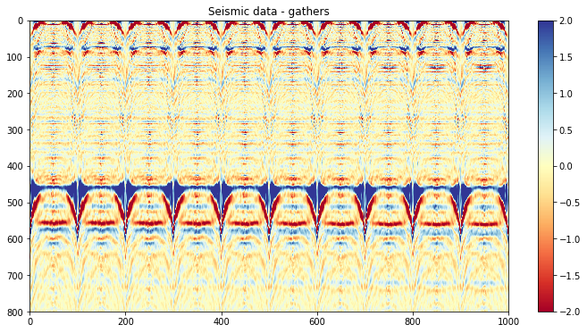

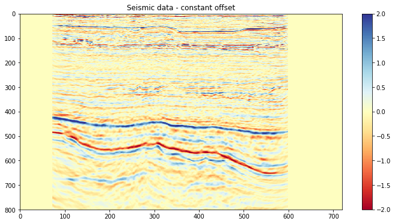

```python
segyfile = '../data/avo/SIKI.680346991.SEGY.00332.ST10010ZC11_PZ_PSDM_RMO_CIP_GATHS_D.3D.PRESTACK_BINGATHERS.000000010221.0001961.0002680'
f = segyio.open(segyfile, ignore_geometry=True)

traces = segyio.collect(f.trace)[:]
traces = traces[:, itmin:itmax]
ntraces, nt = traces.shape

t = f.samples[itmin:itmax]
il = f.attributes(segyio.TraceField.INLINE_3D)[:]
xl = f.attributes(segyio.TraceField.CROSSLINE_3D)[:]
off = f.attributes(segyio.TraceField.offset)[:]

# Define regular IL and XL axes
il_unique = np.unique(il)
xl_unique = np.unique(xl)
off_unique = np.unique(off)

xl_min, xl_max = min(xl_unique), max(xl_unique)
off_min, off_max = min(off_unique), max(off_unique)

dt = t[1] - t[0]
dxl = min(np.unique(np.diff(xl_unique)))
doff = min(np.unique(np.diff(off_unique)))

xlines = np.arange(xl_min, xl_max + dxl, dxl)
offsets = np.arange(off_min, off_max + doff, doff)
nxl, noff = xlines.size, offsets.size

xlgrid, offgrid = np.meshgrid(np.arange(nxl),
                              np.arange(noff),
                              indexing='ij')

# Look-up table
traces_indeces = np.full((nxl, noff), np.nan)
ixls = (xl - xl_min) // dxl
ioffs = (off - off_min) // doff
traces_indeces[ixls, ioffs] = np.arange(ntraces)
traces_available = np.logical_not(np.isnan(traces_indeces))

# Reorganize traces in regular grid
d = np.zeros((nxl, noff, nt))
d[xlgrid.ravel()[traces_available.ravel()],
  offgrid.ravel()[traces_available.ravel()]] = traces

# Subsample
d = d[::jxl, :, ::jt]
xlines = xlines[::jxl]
t = t[::jt]
nxl, nt = len(xlines), len(t)

# Display data
plt.figure(figsize=(12, 6))
plt.imshow((d.reshape(nxl*noff, nt).T)[:, nxl*noff//2-500:nxl*noff//2+500], cmap='RdYlBu', vmin=-2, vmax=2)
plt.title('Seismic data - gathers')
plt.colorbar()
plt.axis('tight')

# Display data
plt.figure(figsize=(12, 6))
plt.imshow(d[:, noff-40].T, cmap='RdYlBu', vmin=-2, vmax=2)
plt.title('Seismic data - constant offset')
plt.colorbar()
plt.axis('tight');
```

We can now remove those far offsets where we do not always have access to data

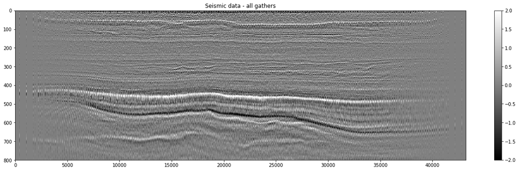

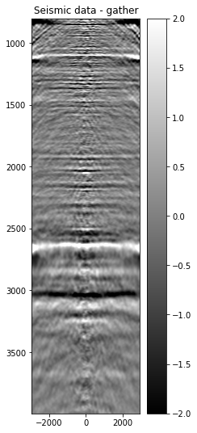

```python
# Subsample
ioffedges = 20
d = d[:, ioffedges:-ioffedges]
offsets = offsets[ioffedges:-ioffedges]
noff = offsets.size

# Display data
plt.figure(figsize=(22, 6))
plt.imshow(d.reshape(nxl*noff, nt).T, cmap='gray', vmin=-2, vmax=2)
plt.title('Seismic data - all gathers')
plt.colorbar()
plt.axis('tight');

# Display data
plt.figure(figsize=(3, 9))
plt.imshow(d[nxl//2].T, cmap='gray', vmin=-2, vmax=2, interpolation='sinc',
           extent=(offsets[0], offsets[-1], t[-1], t[0]))
plt.title('Seismic data - gather')
plt.colorbar()
plt.axis('tight');
```

Let's now try to get a quick estimate of the wavelet in our data using a simple statistical wavelet estimation in frequency domain.

Note that this notebook is not focused on the pre-processing but we will need access to this to apply a colored inversion.

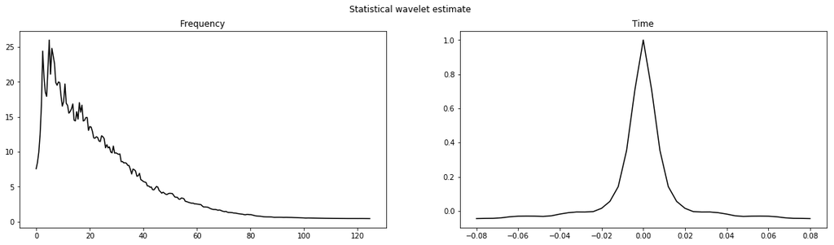

```python
# Wavelet time axis
t_wav = np.arange(nt_wav) * (dt/1000)
t_wav = np.concatenate((np.flipud(-t_wav[1:]), t_wav), axis=0)

# Estimate wavelet spectrum
wav_est_fft = np.mean(np.abs(np.fft.fft(d, nfft, axis=-1)), axis=(0, 1))
fwest = np.fft.fftfreq(nfft, d=dt/1000)

# Create wavelet in time
wav_est = np.real(np.fft.ifft(wav_est_fft)[:nt_wav])
wav_est = np.concatenate((np.flipud(wav_est[1:]), wav_est), axis=0)
wav_est = wav_est / wav_est.max()

# Display wavelet
fig, axs = plt.subplots(1, 2, figsize=(20, 5))
fig.suptitle('Statistical wavelet estimate')
axs[0].plot(fwest[:nfft//2], wav_est_fft[:nfft//2], 'k')
axs[0].set_title('Frequency')
axs[1].plot(t_wav, wav_est, 'k')
axs[1].set_title('Time');
```